# The Great Bay Leaf Experiment: Model

Abby Kaplan

December 7, 2018

## Background

This page is for people who are interested in the technical details of the statistical model. Click here for background on what the study is all about.

## Model(s)

### Outcome and parameters

The outcome variable, $\mbox{prefer.bay.leaf}$, is binary. Let’s do a logistic regression. In addition to the overall intercept, we’ll have adjustments to the intercept by batch, subject, and pair.

$$\mbox{prefer.bay.leaf} = \mbox{Bernoulli}(\mbox{logit}^{-1}(\beta + \gamma_i\sigma_{\gamma_i} + \delta_j\sigma_{\delta_j} + \epsilon_k\sigma_{\epsilon_k}))$$

- $\beta$ is the intercept: the overall preference for portions with bay leaf. This is the parameter we’re most interested in.
- $\gamma_i$ is the adjustment to the intercept for batch $i$.
- $\delta_j$ is the adjustment to the intercept for subject $j$, nested within batch $i$.
- $\epsilon_k$ is the adjustment to the intercept for pair $k$, nested within batch $i$.

(In real life, subjects weren’t actually nested within batches; some subjects – including me – participated in multiple batches. But, to preserve subjects’ privacy, I haven’t tracked subject identity across batches.)

I’m going to try a series of models, each of which adds one more set of parameters, to evaluate whether all these parameters are actually helpful:

| Model | Overall ($\beta$) | Batch ($\gamma$) | Subject ($\delta$) | Pair ($\epsilon$) |
| --- | --- | --- | --- | --- |
| 1 | Y |  |  |  |
| 2 | Y | Y |  |  |
| 3 | Y | Y | Y |  |
| 4 | Y | Y | Y | Y |

### Priors

Let’s put a weak prior of $\mbox{N}(0, 2)$ on $\beta$. Since prior is centered at zero, it will make our model somewhat conservative.

$$\beta \sim \mbox{N}(0, 2)$$

I’m including a parameter for the standard deviation of each of the group-level intercepts, and giving each of these $\sigma$ parameters a half-Cauchy prior.

Priors for batches:

$$\sigma_\gamma \in [0, \inf] \sim \mbox{Cauchy}(0, 1)$$

$$\gamma_i \sim \mbox{N}(0, 1)$$

$$\sigma_\delta \in [0, \inf] \sim \mbox{Cauchy}(0, 1)$$

$$\delta_j \sim \mbox{N}(0, 1)$$

$$\sigma_\epsilon \in [0, \inf] \sim \mbox{Cauchy}(0, 1)$$

$$\epsilon_k \sim \mbox{N}(0, 1)$$

## Simulated data

To test the specification of the model, let’s simulate some data and test whether we can recover the true parameters.

### Simulated inputs

For a large dataset, I would create a much smaller simulated dataset with inputs that have approximately the same distribution as the inputs in the full dataset – to save time. But we’re working with much smaller amounts of data here, so I’ll just copy the actual inputs. Simulating the actual size of the real dataset also has the advantage that it gives us some sense of how precisely we’ll be able to estimate our parameters.

```r
# Set up a dataframe for simulated data.
sim.df = obs.df %>%
  filter(!is.na(prefer.bay.leaf)) %>%
  dplyr::select(obs.id, int.batch.id, int.subject.id, int.pair.id)
# List the simulations we're going to run, and their properties.
simulations = data.frame(
  sim = 1:5,
  model.for.generation = c(1:4, 3),
  model.for.fitting = c(1:4, 2)
)
```

### Simulated parameters

```r
# Simulate parameters by drawing from their priors.  For simulation purposes,
# beta is drawn from a much narrower distribution than its prior in the model.
true.params.sim.df = data.frame(
  draw.id = 1,
  beta = rnorm(1, 0, 0.5),
  sigma_gamma = abs(rcauchy(1, 0, 1)),
  sigma_delta = abs(rcauchy(1, 0, 1)),
  sigma_epsilon = abs(rcauchy(1, 0, 1))
)
true.params.sim.df[,paste("gamma.", sort(unique(obs.df$int.batch.id)), ".", sep = "")] =
  rnorm(length(unique(obs.df$int.batch.id)), 0, 1)
true.params.sim.df[,paste("delta.", sort(unique(obs.df$int.subject.id)), ".", sep = "")] =
  rnorm(length(unique(obs.df$int.subject.id)), 0, 1)
true.params.sim.df[,paste("epsilon.", sort(unique(obs.df$int.pair.id)), ".", sep = "")] =
  rnorm(length(unique(obs.df$int.pair.id)), 0, 1)
true.params.sim.long.df = true.params.sim.df %>%
  gather(parameter, true.value)
```

### Simulated outcomes

For each model, the simulated data includes only those effects that are actually modeled. (I.e., for models that don’t include subject-level effects, the simulation process doesn’t have any subject-level effects.) But, for reasons discussed below, let’s also run a fifth simulation where we won’t model subject-level effects when fitting the data (model 2), but where the simulated data *does* have subject-level effects (i.e., the structure of model 3).

```r
# A utility function that simulates outcomes for a given model and a given set
# of parameter draws; we'll use this both to generate outcomes for the
# simulated datasets and to do posterior predictive checking.
generate.outcomes = function(inputs.df, parameters.df, n.draws, model) {
  # Set up the dataframe to hold both inputs and generated outcomes.
  outputs.df = inputs.df
  # Create model matrices for batch, subject, and pair (if needed).
  if(is.element(model, 2:4)) {
    mm.batch = model.matrix(~ factor(int.batch.id), outputs.df,
                            contrasts.arg =
                              list("factor(int.batch.id)" =
                                     contrasts(factor(outputs.df$int.batch.id),
                                               contrasts = F)))[,-1]
  }
  if(is.element(model, 3:4)) {
    mm.subject = model.matrix(~ factor(int.subject.id), outputs.df,
                              contrasts.arg =
                                list("factor(int.subject.id)" =
                                     contrasts(factor(outputs.df$int.subject.id),
                                               contrasts = F)))[,-1]
  }
  if(is.element(model, 4)) {
    mm.pair = model.matrix(~ factor(int.pair.id), outputs.df,
                           contrasts.arg =
                             list("factor(int.pair.id)" =
                                    contrasts(factor(outputs.df$int.pair.id),
                                              contrasts = F)))[,-1]
  }
  # Randomly draw from the parameters the specified number of times.
  draws.df = sample_n(parameters.df, n.draws, replace = T)
  # Create the matrix of data and the matrix of parameters.
  data.matrix = cbind(rep(1, nrow(outputs.df)))
  param.matrix = cbind(draws.df$beta)
  if(is.element(model, 2:4)) {
    data.matrix = cbind(data.matrix,
                        mm.batch)
    param.matrix = cbind(param.matrix,
                         draws.df[,paste("gamma.",
                                         sort(unique(outputs.df$int.batch.id)),
                                         ".", sep = "")] * draws.df$sigma_gamma)
  }
  if(is.element(model, 3:4)) {
    data.matrix = cbind(data.matrix,
                        mm.subject)
    param.matrix = cbind(param.matrix,
                         draws.df[,paste("delta.",
                                         sort(unique(outputs.df$int.subject.id)),
                                         ".", sep = "")] * draws.df$sigma_delta)
  }
  if(is.element(model, 4)) {
    data.matrix = cbind(data.matrix,
                        mm.pair)
    param.matrix = cbind(param.matrix,
                         draws.df[,paste("epsilon.",
                                         sort(unique(outputs.df$int.pair.id)),
                                         ".", sep = "")] * draws.df$sigma_epsilon)
  }
  # Generate the probability of preferring bay leaf for each observation and
  # for each draw.
  prefer.bay.leaf.prob.pred = invlogit(data.matrix %*% t(param.matrix))
  # Convert each probability to a prediction (i.e., sample from the
  # probability) and add the predictions to the data frame.
  prefer.bay.leaf.preds = matrix(ifelse(prefer.bay.leaf.prob.pred >
                                          runif(length(prefer.bay.leaf.prob.pred),
                                                       0, 1), 1, 0),
                                 ncol = ncol(prefer.bay.leaf.prob.pred))
  outputs.df = cbind(outputs.df,
                     prefer.bay.leaf.preds)
  # Convert the dataframe from wide to long.
  outputs.df = outputs.df %>%
    gather(draw.id, prefer.bay.leaf.pred, -obs.id, -int.batch.id,
           -int.subject.id, -int.pair.id) %>%
    dplyr::select(obs.id, int.batch.id, int.subject.id, int.pair.id,
                  prefer.bay.leaf.pred)
  return(outputs.df)
}
# Use the function to generate simulated outcomes for each of the four models.
for(i in 1:5) {
  model = simulations$model.for.generation[simulations$sim == i]
  temp = generate.outcomes(sim.df %>%
                             dplyr::select(obs.id, int.batch.id,
                                           int.subject.id, int.pair.id),
                           true.params.sim.df, 1, model)
  sim.df[,paste("prefer.bay.leaf", i, sep = ".")] = temp$prefer.bay.leaf.pred == 1
  sim.df[,paste("int.prefer.bay.leaf", i, sep = ".")] = temp$prefer.bay.leaf.pred
}
rm(i, model, temp)
```

### Fit the simulated data

```r
# Create the datasets for Stan.
sim.data.for.stan = list()
for(i in 1:5) {
  model = simulations$model.for.fitting[simulations$sim == i]
  temp = list(N = nrow(sim.df),
              prefer_bay_leaf = sim.df[,paste("int.prefer.bay.leaf", i, sep = ".")])
  if(is.element(model, 2:4)) {
    temp[["I"]] = max(sim.df$int.batch.id)
    temp[["batch"]] = sim.df$int.batch.id
  }
  if(is.element(model, 3:4)) {
    temp[["J"]] = max(sim.df$int.subject.id)
    temp[["subject"]] = sim.df$int.subject.id
  }
  if(is.element(model, 4)) {
    temp[["K"]] = max(sim.df$int.pair.id)
    temp[["pair"]] = sim.df$int.pair.id
  }
  sim.data.for.stan[[i]] = temp
}
rm(i, model, temp)
# Fit each model.
fit.sim.stan = list()
for(i in 1:5) {
  model = simulations$model.for.fitting[simulations$sim == i]
  temp = stan(paste("bay_leaf_analysis_", model, ".stan", sep = ""),
              data = sim.data.for.stan[[i]],
              chains = 4, iter = 2000,
              control = list(adapt_delta = 0.99))
  fit.sim.stan[[i]] = temp
}
rm(i, model, temp)
```

### Check the fit of the simulated data

There were no divergent transitions. The chains are stationary and well mixed.

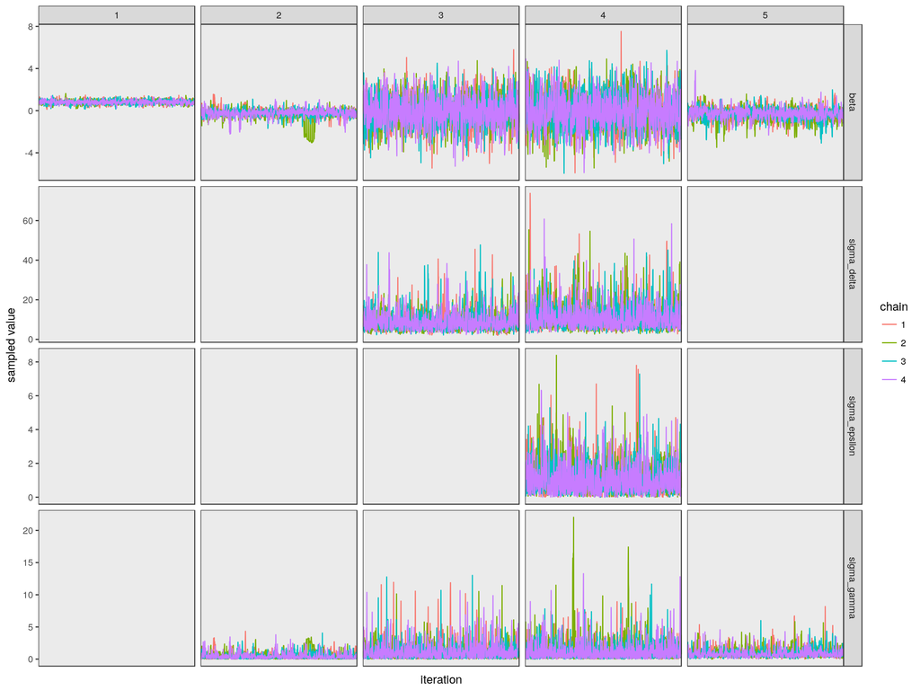

```r
# Extract the sampled parameter values.
sampled.params.sim.df = bind_rows(lapply(fit.sim.stan,
                                         function(x) {
                                           temp.array = as.array(x)
                                           temp.df = bind_rows(
                                             lapply(1:4,
                                                    function(x) {
                                                      data.frame(temp.array[,x,]) %>%
                                                        setNames(gsub("[[]|[]]", "\\.", colnames(.))) %>%
                                                        rownames_to_column("iteration")
                                                      }),
                                             .id = "chain")
                                           return(temp.df)
                                           }),
                                  .id = "simulation")
sampled.params.sim.long.df = sampled.params.sim.df %>%
  gather(parameter, sampled.value, -simulation, -chain, -iteration) %>%
  filter(parameter != "lp__" & !is.na(sampled.value)) %>%
  mutate(parameter.group = gsub("^(gamma|delta|epsilon).*", "\\1", parameter))
# Plot the chains.
sampled.params.sim.long.df %>%
  filter(grepl("beta|sigma", parameter)) %>%
  ggplot(aes(x = iteration, y = sampled.value, col = chain)) +
  geom_line(aes(group = chain)) +
  facet_grid(parameter ~ simulation, scales = "free") +
  scale_y_continuous("sampled value") +
  theme(axis.ticks.x = element_blank(),
        axis.text.x = element_blank())
```

### Did the model capture the true parameter values?

The model has done a decent job of capturing the true values of $\beta$, $\sigma_\gamma$, $\sigma_\delta$, and $\sigma_\epsilon$ (plotted in red). But when we add subject-level effects, the model has a much harder time finding $\beta$; in these simulations, the effect of bay leaf would have to be huge in order for us to detect it with confidence.

But there’s good news. In simulation 5 (which didn’t model subject-level effects even though they were used to generate the data), $\beta$ is estimated with much more confidence, and the estimate appears to be just as accurate as the estimate in simulation 2. ($\beta$ is slightly underestimated in all the models after the first one; this is because all the simulated $\gamma$ parameters happened to be negative. Stan assigns some of that dispreference for bay leaf to $\beta$ instead of to all the individual $\gamma$s.) All in all, this suggests that it should be safe to omit subject-level effects from the model, even if we strongly suspect that they might be present.

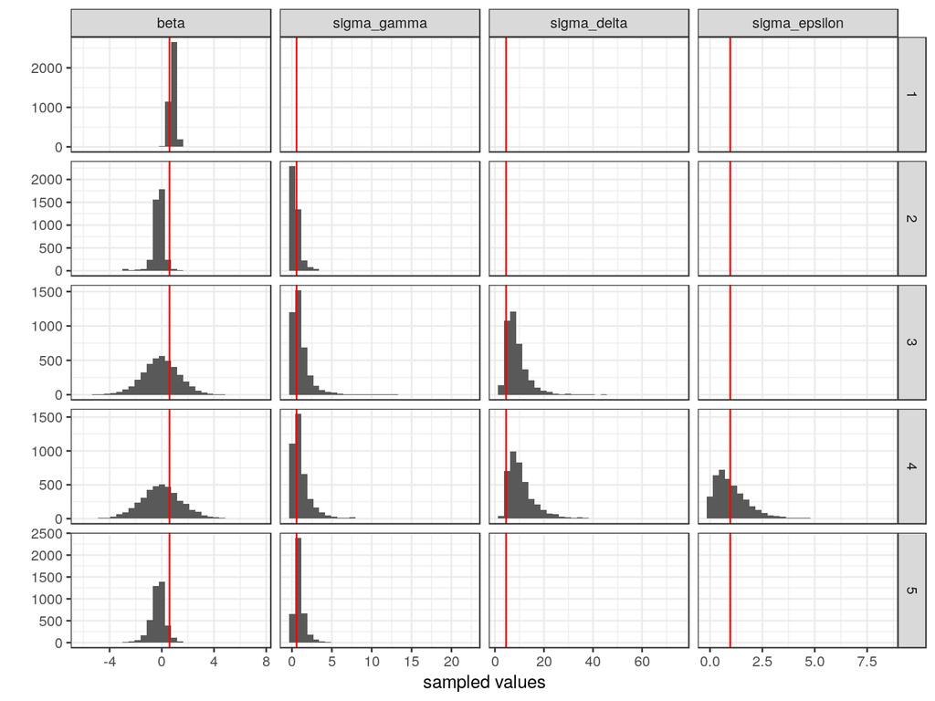

```r
sampled.params.sim.long.df %>%
  filter(grepl("beta|sigma", parameter)) %>%
  mutate(parameter = factor(parameter,
                            levels = c("beta", "sigma_gamma", "sigma_delta",
                                       "sigma_epsilon"))) %>%
  ggplot(aes(x = sampled.value)) +
  # geom_density(fill = "lightgray", size = 0.3) +
  geom_histogram() +
  geom_vline(data = true.params.sim.long.df %>%
               filter(grepl("beta|sigma", parameter)) %>%
               mutate(parameter = factor(parameter,
                                         levels = c("beta", "sigma_gamma",
                                                    "sigma_delta", "sigma_epsilon"))),
             aes(xintercept = true.value),
             col = "red") +
  facet_grid(simulation ~ parameter, scale = "free") +
  scale_x_continuous("sampled values") +
  scale_y_continuous("")
```

The model does less well in recovering the group-level intercepts $\gamma_i$, $\delta_j$, and $\epsilon_k$. This isn’t shocking, since we have so few observations for each group. The shrinkage towards zero is especially obvious for the $\delta_j$ intercepts, and there seems to be a limit to how far from zero the model is capable of estimating at all.

At any rate, the recovered parameter values are so unreliable that I’m reluctant to try to do much in the way of inference on the real data at all. At best, if the samples for a given parameter are reliably on one side of zero, we might be able to conclude that there’s a real effect of bay leaf in that group. But *lack* of an effect should be interpreted with extreme caution, because of the wide credible intervals and the shrinkage toward zero.

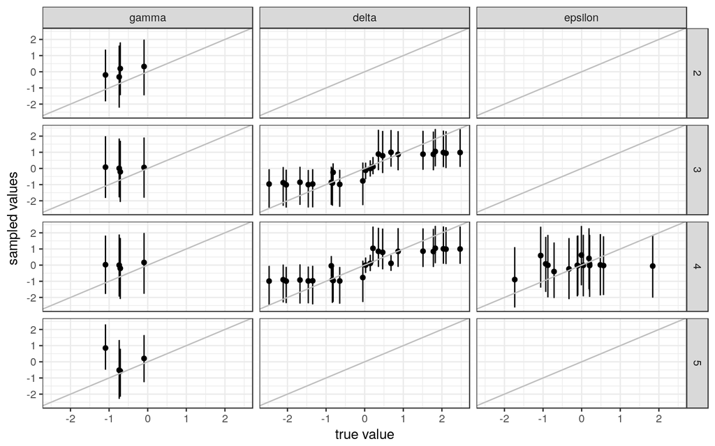

```r
sampled.params.sim.long.df %>%
  filter(grepl("^(gamma|delta|epsilon)", parameter)) %>%
  mutate(parameter.group = factor(parameter.group,
                                  levels = c("gamma", "delta", "epsilon"))) %>%
  group_by(simulation, parameter.group, parameter) %>%
  summarize(mean.sampled.value = mean(sampled.value),
            upper.bound = quantile(sampled.value, 0.975),
            lower.bound = quantile(sampled.value, 0.025)) %>%
  inner_join(true.params.sim.long.df, by = c("parameter")) %>%
  ggplot(aes(x = true.value, y = mean.sampled.value)) +
  geom_point() +
  geom_errorbar(aes(ymin = lower.bound, ymax = upper.bound)) +
  geom_abline(intercept = 0, slope = 1, col = "gray") +
  facet_grid(simulation ~ parameter.group) +
  scale_x_continuous("true value") +
  scale_y_continuous("sampled values")
```

### Posterior predictive checks

The predictions are…not great. For such a small dataset, though, I suppose they could be worse. Part of the problem is that we just can’t make strong predictions about most of the data points. Comfortingly, simulation 5 (with the simplified model 2 and the more complex data-generating process 3) seems to be no worse than any of the others.

```r
# Generate predicted outputs for the simulated data based on the fitted model.
for(i in 1:5) {
  model = simulations$model.for.fitting[simulations$sim == i]
  temp = generate.outcomes(sim.df,
                           sampled.params.sim.df %>%
                             filter(simulation == i),
                           1000, model) %>%
    group_by(obs.id) %>%
    summarize(mean.pred = mean(prefer.bay.leaf.pred))
  sim.df[,paste("mean.pred", i, sep = ".")] = data.frame(temp)$mean.pred
}
rm(i, temp, model)
```

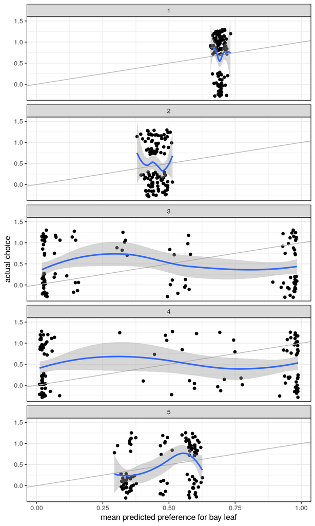

```r
ggplot(sim.df %>%
         dplyr::select(-matches("int\\..*\\.id")) %>%
         dplyr::select(-matches("^prefer")) %>%
         gather(measure, value, -obs.id) %>%
         mutate(simulation = gsub("^.*([0-9]+).*$", "\\1", measure)) %>%
         mutate(measure = gsub("\\.[0-9]", "", measure)) %>%
         spread(measure, value),
       aes(x = mean.pred, y = int.prefer.bay.leaf)) +
  geom_jitter(height = 0.3, width = 0) +
  geom_abline(intercept = 0, slope = 1, col = "gray") +
  stat_smooth() +
  facet_wrap(~ simulation, ncol = 1) +
  scale_x_continuous("mean predicted preference for bay leaf") +
  scale_y_continuous("actual choice")
```

## Fit the real data

We’ll fit the real dataset with batch-level effects only, not subject- or pair-level effects.

```r
# Create the dataset for Stan.
data.for.stan = list(N = nrow(obs.df[!is.na(obs.df$prefer.bay.leaf),]),
                     I = max(obs.df[!is.na(obs.df$prefer.bay.leaf),]$int.batch.id),
                     batch = obs.df[!is.na(obs.df$prefer.bay.leaf),]$int.batch.id,
                     prefer_bay_leaf = obs.df[!is.na(obs.df$prefer.bay.leaf),]$int.prefer.bay.leaf)
# Fit the model.
fit.stan = stan("bay_leaf_analysis_2.stan",
                data = data.for.stan,
                chains = 4, iter = 2000,
                control = list(adapt_delta = 0.99))
```

### Check the fit of the model

No divergent transitions. The chains look great.

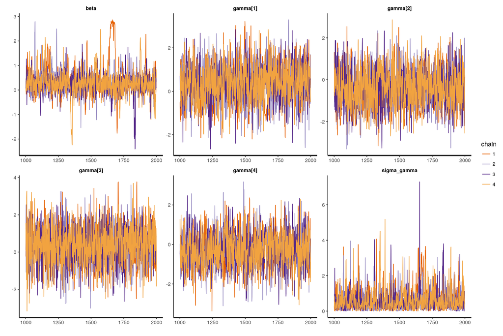

### Posterior predictive checks

```r
# Extract the sampled parameter values from the model fit.
sampled.params.df = as.data.frame(fit.stan) %>%
  setNames(gsub("[[]|[]]", "\\.", colnames(.))) %>%
  rownames_to_column("draw.id")
sampled.params.long.df = sampled.params.df %>%
  gather(parameter, sampled.value, -draw.id) %>%
  mutate(parameter.group =  gsub("^.*(beta|gamma|delta|epsilon).*$", "\\1", parameter),
         parameter.num = as.numeric(gsub("^.*\\.([0-9]+)\\..*$", "\\1", parameter)))
# Generate predicted outputs for the real data based on the fitted model.
pred.df = generate.outcomes(obs.df[!is.na(obs.df$prefer.bay.leaf),],
                            sampled.params.df,
                            1000, 2) %>%
  group_by(obs.id) %>%
  summarize(mean.pred = mean(prefer.bay.leaf.pred)) %>%
  inner_join(obs.df, by = c("obs.id"))
```

The posterior predictions actually look pretty good, especially compared to the simlations. But it’s worth noticing that the predictions fall within a really narrow range – from 51% to 65%. Could it be that we’re just seeing a model that, much of the time, correctly predicts “meh”?

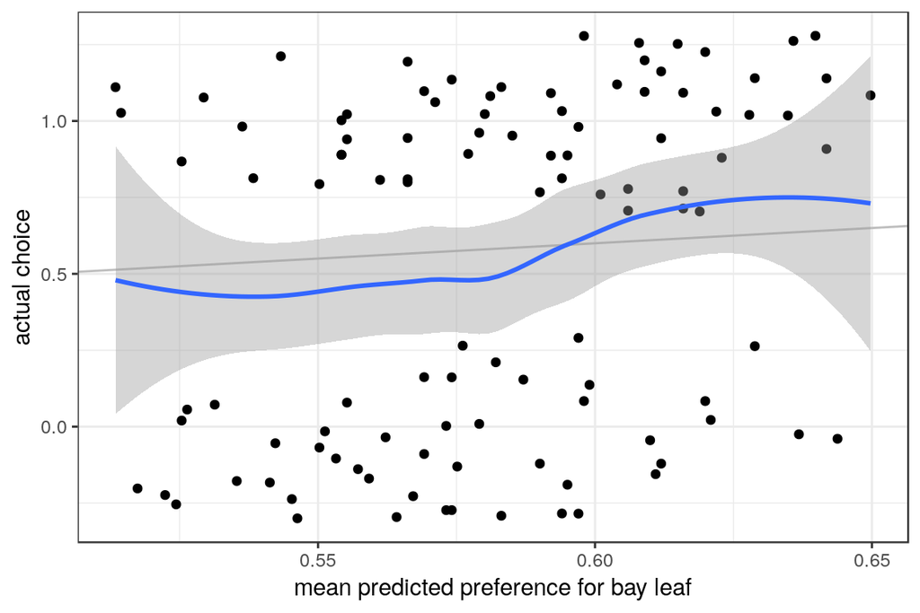

```r
# Plot the predicted vs. real outcomes.
ggplot(pred.df, aes(x = mean.pred, y = int.prefer.bay.leaf)) +
  geom_jitter(height = 0.3, width = 0) +
  geom_abline(intercept = 0, slope = 1, col = "gray") +
  stat_smooth() +
  scale_x_continuous("mean predicted preference for bay leaf") +
  scale_y_continuous("actual choice")
```